# Лабораторная работа №4

Адресация IPv4 и IPv6. Двойной стек

Цыкунова Екатерина Михайловна

1132246732@rudn.ru

Российский университет дружбы народов

2026-10-09

# Цели и задачи работы

## Цель лабораторной работы

Приобретение практических навыков настройки адресации IPv4 и IPv6, организации двойного стека сетевых протоколов, маршрутизации между подсетями и анализа сетевого трафика в GNS3.

## Задачи лабораторной работы

- настроить IPv4-адресацию на оконечных устройствах и маршрутизаторе FRR;
- настроить IPv6-адресацию на оконечных устройствах и маршрутизаторе VyOS;
- организовать двойной стек IPv4 и IPv6 на сервере;
- проанализировать трафик ARP, ICMP и ICMPv6 в Wireshark;
- выполнить самостоятельное задание по настройке двух подсетей с двойным стеком адресации.

# Настройка двойного стека IPv4 и IPv6

## Создаю топологию сети

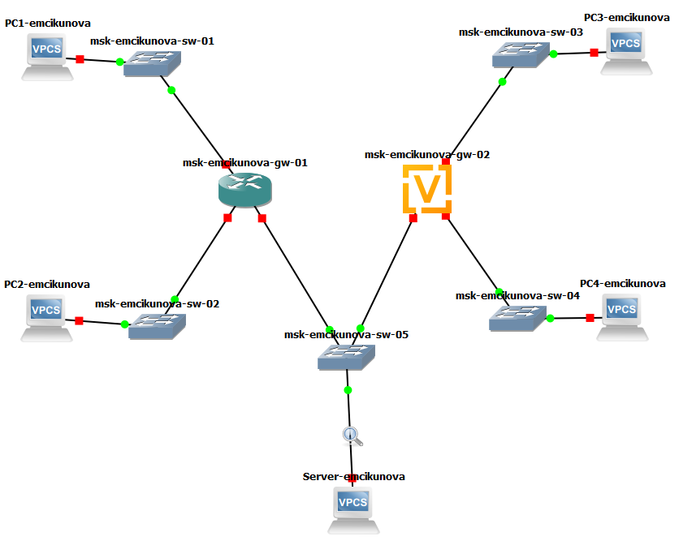

Топология сети с IPv4- и IPv6-подсетями

## Настраиваю IPv4-адресацию оконечных устройств

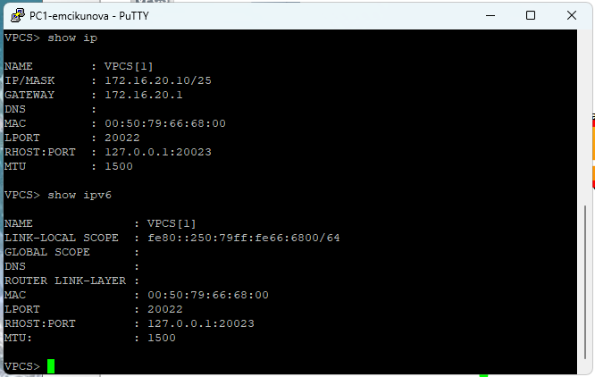

Проверка IPv4-адресации компьютера PC1

## Настраиваю IPv4-адресацию сервера

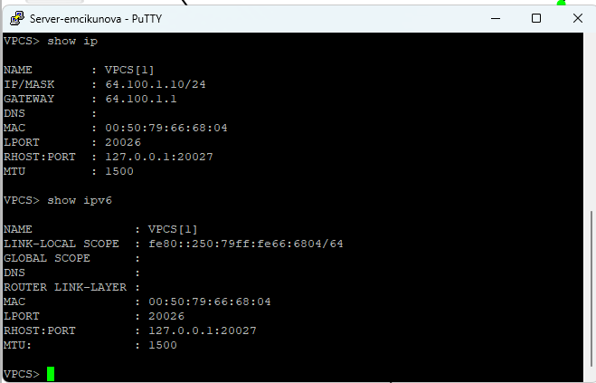

Настройка IPv4-адресации сервера

# Настройка маршрутизатора FRR

## Настраиваю интерфейсы FRR

[figure not shown]

Настройка интерфейсов маршрутизатора FRR

## Проверяю конфигурацию FRR

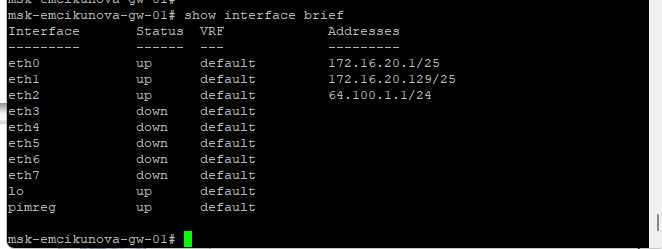

Проверка интерфейсов маршрутизатора FRR

## Проверяю соединение в IPv4-сети

[figure not shown]

Проверка соединения PC1 с PC2 и сервером

# Настройка IPv6-адресации

## Настраиваю IPv6 на оконечных устройствах

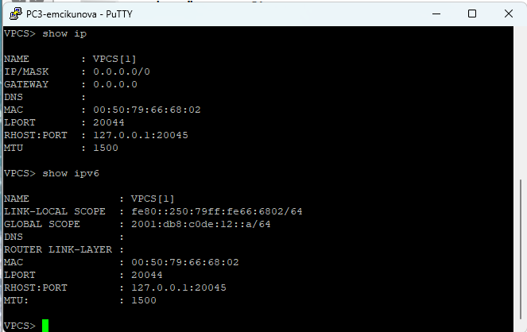

Проверка IPv6-адресации компьютера PC3

## Настраиваю двойной стек на сервере

[figure not shown]

Проверка двойного стека IPv4 и IPv6 на сервере

# Настройка маршрутизатора VyOS

## Настраиваю IPv6-интерфейсы VyOS

[figure not shown]

Настройка IPv6-адресов маршрутизатора VyOS

## Проверяю интерфейсы VyOS

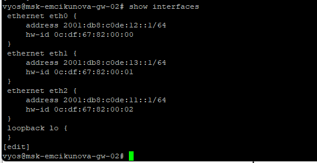

Проверка интерфейсов маршрутизатора VyOS

## Проверяю соединение в IPv6-сети

[figure not shown]

Проверка IPv6-соединения PC3 с PC4 и сервером

## Проверяю работу двойного стека

[figure not shown]

Проверка соединения сервера с устройствами IPv4 и IPv6

# Анализ сетевого трафика

## Анализирую ARP-трафик

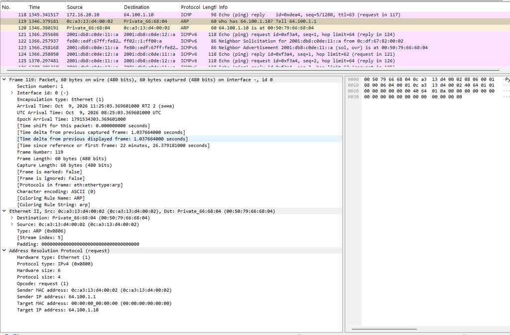

Анализ ARP-запросов и ответов в Wireshark

## Анализирую ICMP-трафик

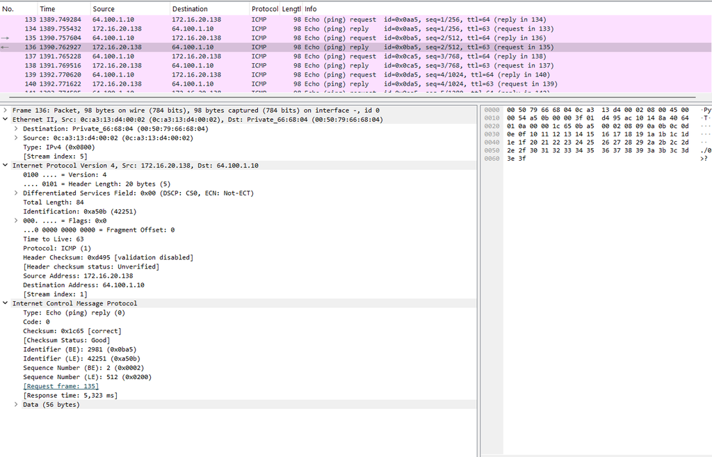

Анализ ICMP-трафика в Wireshark

## Анализирую ICMPv6-трафик

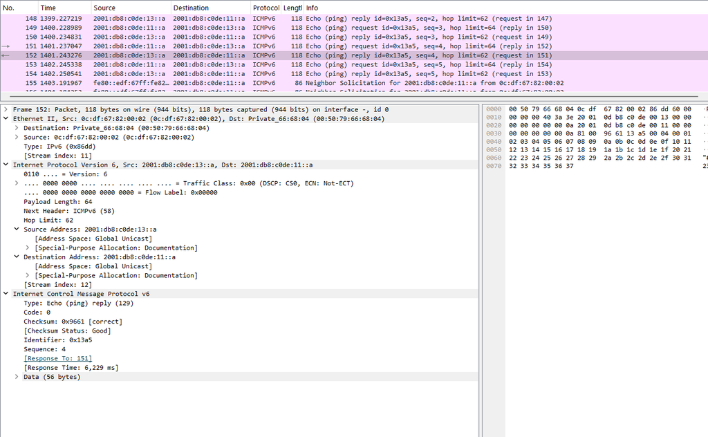

Анализ ICMPv6-трафика в Wireshark

# Самостоятельное задание

## Определяю параметры подсетей

Для самостоятельного задания использую две подсети с двойным стеком адресации:

- Подсеть 1: `10.10.1.96/27` и `2001:db8:1:1::/64`;
- Подсеть 2: `10.10.1.16/28` и `2001:db8:1:4::/64`.

Первая IPv4-подсеть содержит 30 доступных адресов узлов, вторая — 14.

Для интерфейсов маршрутизатора выбираю наименьшие доступные адреса: `10.10.1.97/27`, `10.10.1.17/28`, `2001:db8:1:1::1/64` и `2001:db8:1:4::1/64`.

## Настраиваю маршрутизатор VyOS

[figure not shown]

Настройка IPv4 и IPv6 на маршрутизаторе VyOS

## Проверяю конфигурацию маршрутизатора

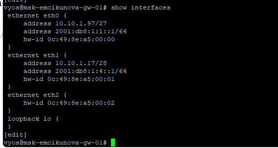

Проверка интерфейсов VyOS в самостоятельном задании

## Настраиваю двойной стек на PC1 и PC2

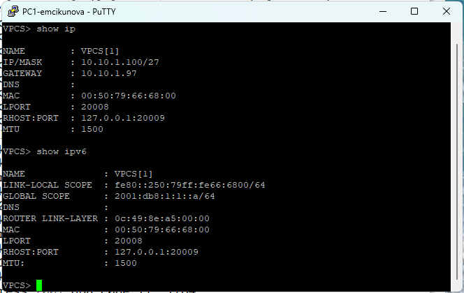

Проверка двойного стека IPv4 и IPv6 на PC1

## Проверяю соединение между подсетями

[figure not shown]

Проверка соединения между подсетями по IPv4 и IPv6

## Проверяю соединение в обратном направлении

[figure not shown]

Проверка соединения с PC2 до PC1 по IPv4 и IPv6

# Вывод

## Результаты лабораторной работы

В ходе лабораторной работы была создана и настроена сеть в GNS3 с использованием протоколов IPv4 и IPv6.

Выполнена настройка маршрутизаторов FRR и VyOS, оконечных устройств и сервера с двойным стеком адресации. С помощью команд `ping` и `trace` проверена связность между устройствами.

В Wireshark проведён анализ трафика ARP, ICMP и ICMPv6.

В самостоятельном задании настроена маршрутизация IPv4 и IPv6 между двумя подсетями. Результаты проверок подтвердили корректность настройки адресации и работоспособность сети.